# Homework 1.3

Lorenzo Foa’ Mehdi El Idrissi

06 novembre 2018

## Homework 1.3a

```r
library(ggplot2)
library(GGally)
library(FactoMineR)
library(factoextra)
library(MASS)
library(dplyr)
```

Performing the PCA on the correlation matrix is equivalent to standardizing each of the variables. In general, PCA with and without standardizing will give different results. Especially when the scales are different. So since we have different scales in my dataset I will use R matrix.

```r
Wines_complete = read.delim("wines.txt", sep = "", dec = ".",header=FALSE,col.names=c('fixedacidity','volatileacidity','citicacid','residualsugar','chlorides','freesulfurdioxide','totalsulfurdioxide','density','pH','sulphates','alcohol','quality','type'))
Wines=select(Wines_complete,fixedacidity,volatileacidity,citicacid,residualsugar,chlorides,freesulfurdioxide,totalsulfurdioxide,density,pH,sulphates,alcohol,type)
Wines=na.omit(Wines)
```

# PCA

The main purpose of principal component analysis is to identify hidden patterns in a data set, to reduce the dimensionnality of the data by removing the noise and redundancy in the data and also to identify correlated variables.

```r
Wines_PCA_r=PCA(Wines, scale.unit = TRUE, ncp = 4, ind.sup = NULL,
                quanti.sup = NULL, quali.sup = 12, row.w = NULL,
                col.w = NULL, graph = F)
```

screeplot

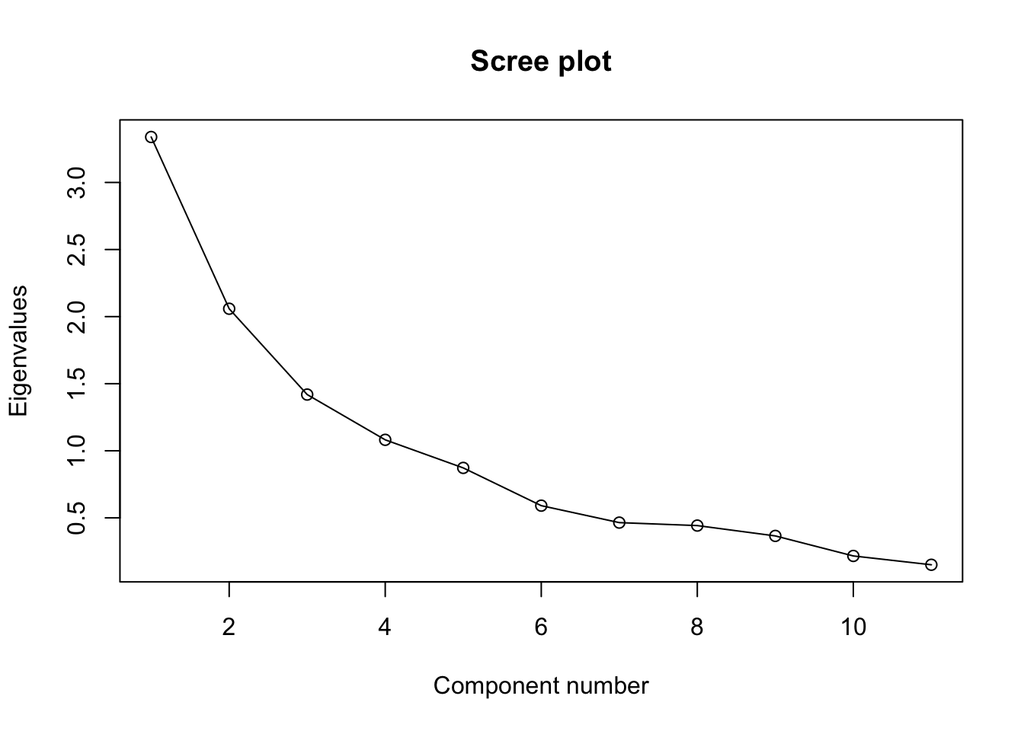

```r
plot(1:length(Wines_PCA_r$eig[,1]),Wines_PCA_r$eig[,1],type = "o",main = "Scree plot",xlab = "Component number",ylab = "Eigenvalues")
```

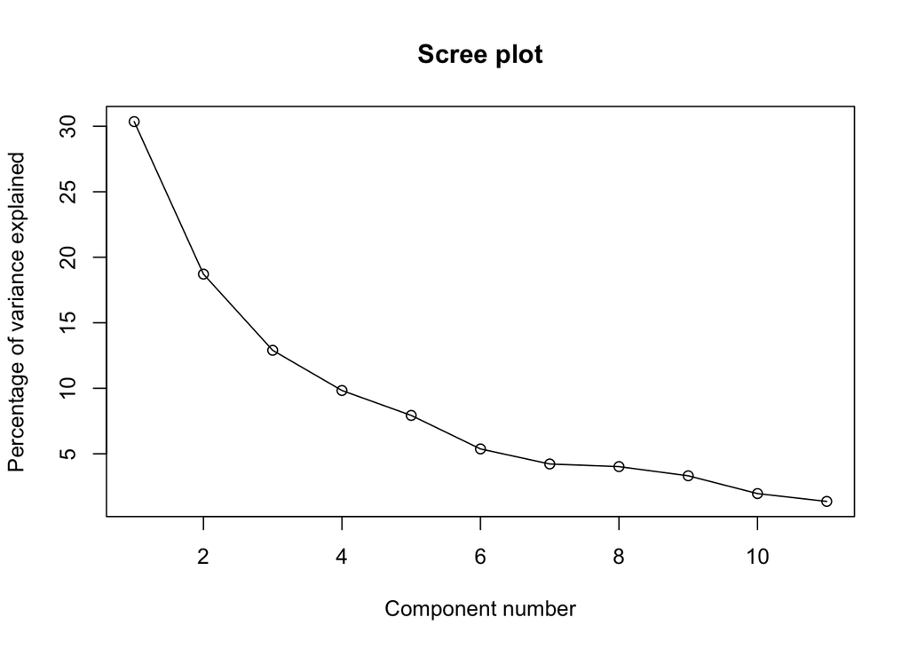

```r
plot(1:length(Wines_PCA_r$eig[,2]),Wines_PCA_r$eig[,2],type = "o",main = "Scree plot",xlab = "Component number",ylab = "Percentage of variance explained")
```

Analytical description of the first 4 principal components

```r
Wines_PCA_r$var$coord
```

```
##                          Dim.1       Dim.2       Dim.3       Dim.4
## fixedacidity       -0.06307131  0.70486549  0.28078131  0.17651915
## volatileacidity    -0.71816017  0.03797768 -0.35504978  0.14824783
## citicacid           0.65769861  0.24988898  0.57180144  0.07178174
## residualsugar       0.58625387  0.17809373 -0.52560344  0.26395225
## chlorides          -0.37883046  0.60207044 -0.04933423 -0.43434698
## freesulfurdioxide   0.76549623  0.01144086 -0.22992253 -0.33645761
## totalsulfurdioxide  0.87394209 -0.05786021 -0.13794863 -0.21830517
## density             0.28397017  0.30617462 -0.16463569  0.75115589
## pH                 -0.51170678 -0.62211246 -0.05545707  0.10536737
## sulphates          -0.44449436  0.65186226  0.17054117 -0.05520159
## alcohol             0.09676625 -0.44098332  0.69077546  0.16037587
```

Variability explained by the first principal component

```r
Wines_PCA_r$eig[1,2]
```

```
## [1] 30.3517
```

Cumulative variance explained by the first 4 variables

```r
Wines_PCA_r$eig[1:4,2:3]
```

```
##        percentage of variance cumulative percentage of variance
## comp 1              30.351697                          30.35170
## comp 2              18.714223                          49.06592
## comp 3              12.898889                          61.96481
## comp 4               9.832574                          71.79738
```

A graphic representation of the variables’ contribute to the first two principal components. For a given dimension, any row/column with a contribution above the reference line could be considered as important in contributing to the dimension.

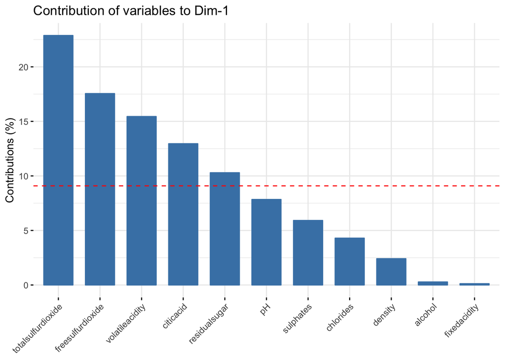

```r
fviz_contrib(Wines_PCA_r, choice = "var", axes = 1, top = 11)
```

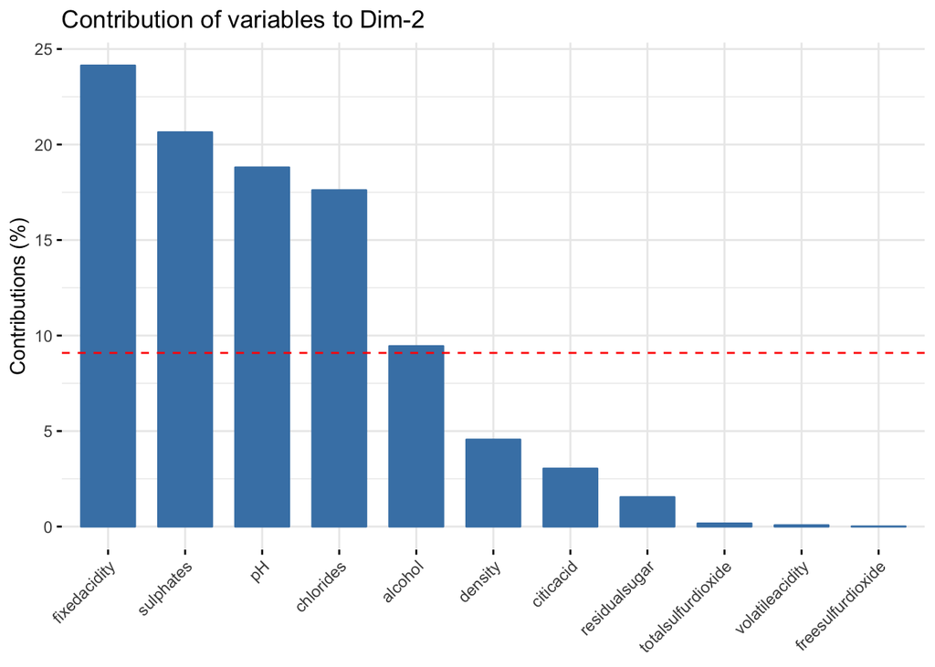

```r
fviz_contrib(Wines_PCA_r, choice = "var", axes = 2, top = 11)
```

The first 4/5 principal components explain most of the variability.

Observations plotted on the first 2 components and coloured by type

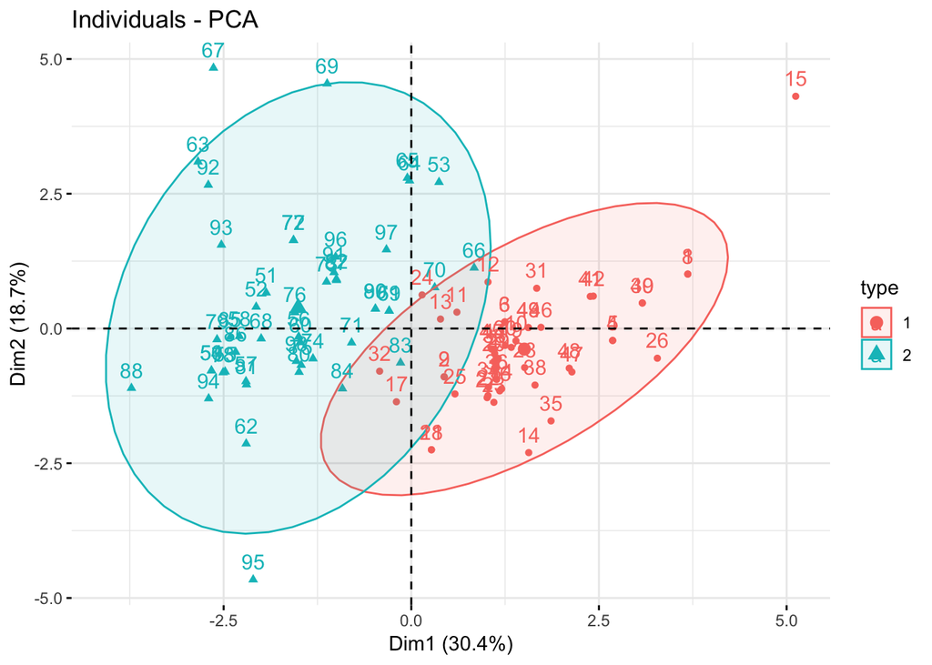

```r
fviz_pca_ind(Wines_PCA_r,habillage = "type", addEllipses = TRUE)
```

The first principal component clearly separates wines by their type: white wines mostly have higher values than red wines. but all the white wines have common charcteristics and red wines as well

Can also see some outliers. Their indexes are:15,67,95.

interpretation pc1 and pc2 The first principal component can be interpreted as some kind of inverse measure of the presence of grape pulp in the production process. If grape pulp is present the wine will be red, if these parts of the plant are discarded, the wine will be white.

The second principal component, since the acidities’ contributions are always positive, can be interpreted as wine’s global acidity.

```r
Wines_PCA_r$var$coord[,2]
```

```
##       fixedacidity    volatileacidity          citicacid
##         0.70486549         0.03797768         0.24988898
##      residualsugar          chlorides  freesulfurdioxide
##         0.17809373         0.60207044         0.01144086
## totalsulfurdioxide            density                 pH
##        -0.05786021         0.30617462        -0.62211246
##          sulphates            alcohol
##         0.65186226        -0.44098332
```

Rerun PCA using quality as supplementary qualitative variable

```r
Wines1=select(Wines_complete,fixedacidity,volatileacidity,citicacid,residualsugar,chlorides,freesulfurdioxide,totalsulfurdioxide,density,pH,sulphates,alcohol,quality)

Wines_PCA_r1=PCA(Wines1, scale.unit = TRUE, ncp = 4, ind.sup = NULL,
                quanti.sup = NULL, quali.sup = 12 , row.w = NULL,
                col.w = NULL, graph = FALSE)
```

Observation on the first 2 components by quality

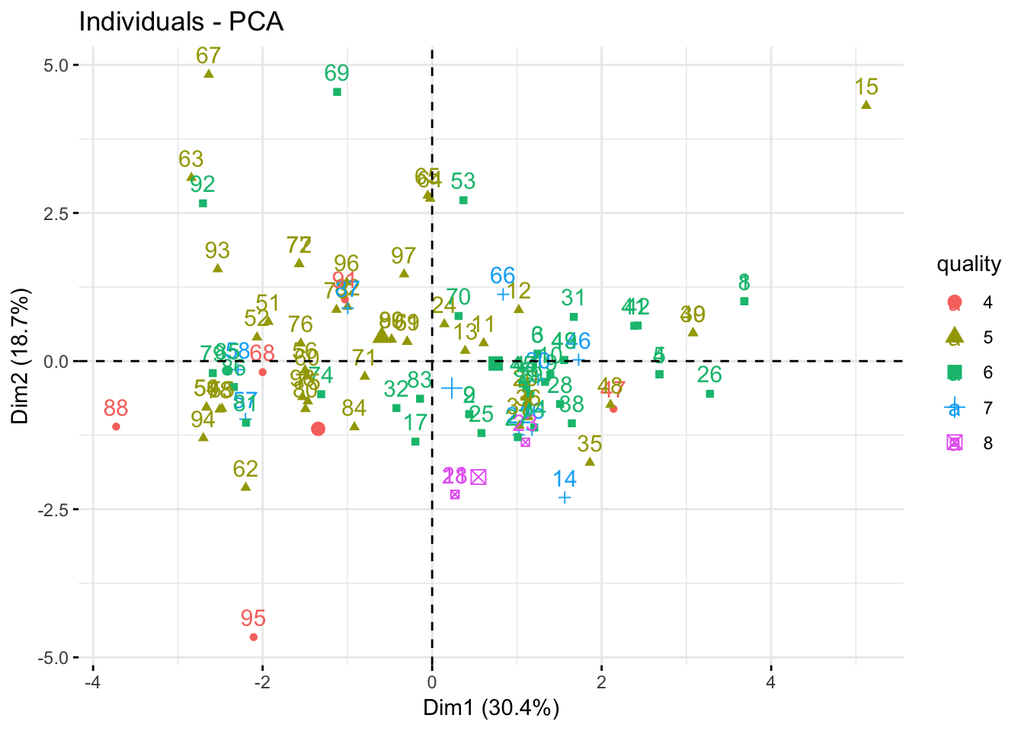

```r
fviz_pca_ind(Wines_PCA_r1,habillage="quality")
```

As we can see form the plot, if we try to group by the quality, there is no pattern.

Lumping quality

```r
Wines1$quality[Wines1$quality<6]=1
Wines1$quality[Wines1$quality==6]=2
Wines1$quality[Wines1$quality>6]=3
```

PCA

```r
Wines_PCA_r1=PCA(Wines1, scale.unit = TRUE, ncp = 4, ind.sup = NULL,
                quanti.sup = NULL, quali.sup = 12, row.w = NULL,
                col.w = NULL, graph = F)
```

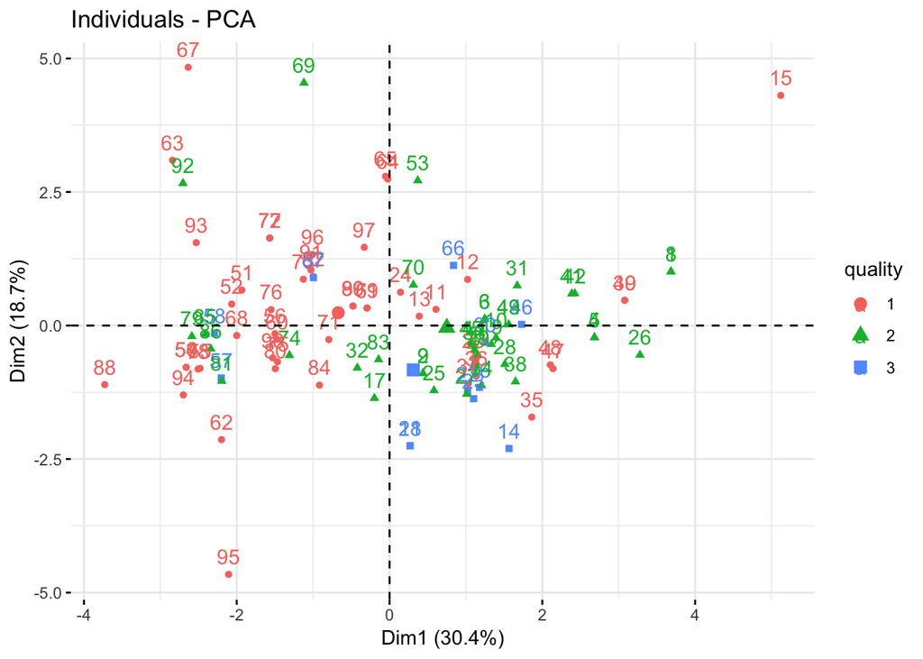

```r
fviz_pca_ind(Wines_PCA_r1,habillage="quality")
```

Trying to separate the data between (more, less or equal than 6) quality’s categories, we can also notice that there’s no pattern in that case.

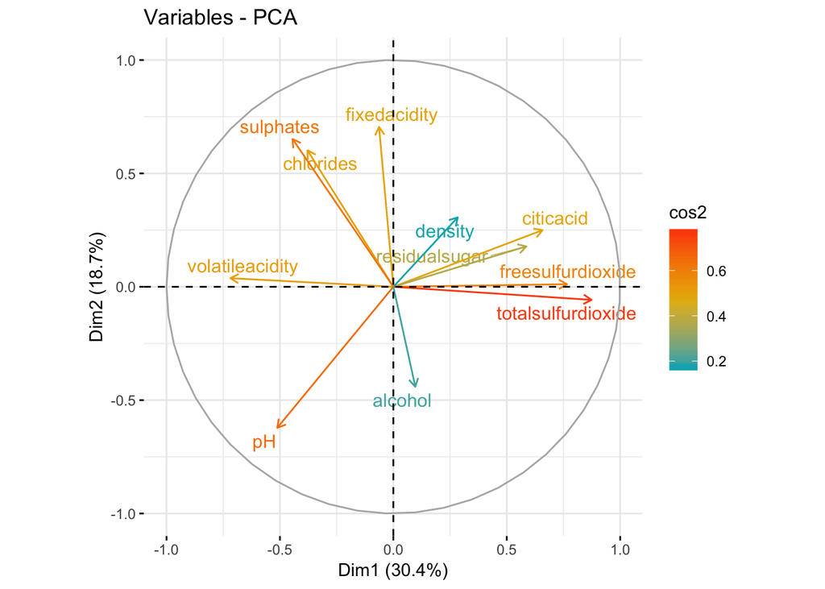

```r
fviz_pca_var(Wines_PCA_r1, col.var = "cos2",
             gradient.cols = c("#00AFBB", "#E7B800", "#FC4E07"),
             repel = TRUE)
```

For the variables : volatileacidity, chlorides, sulphates, fixedacidity, citicacid, freesulfudioxide, totalsulfurdioxide and Ph, cos2 is high because the variable are positioned close to the circumference of the correlation circle. This indicates a good representation of the variables on the principal component.